# LIS Oyster Lab Tissue Processing

2/12/26 by M.Kachmar - added some preliminary statistics for body condition

### This code chunk merges all .csv files within the Tissue processing folder into one data frame and outputs the full dataset into a .csv master file. This allows us to download the raw data as a .csv, add it to the repository folder, and create the master data file without copying and pasting data in excel.

# reading in .csv files from local folder

```r
#data_all <- list.files(path = "Lab_Data_TissueProcessing/raw_data/Files_by_Month",                           # Identify all CSV files
# pattern = "*.csv", full.names = TRUE) %>%
#lapply(read_csv) %>%   # Store all files in list
#  bind_rows          # Combine data sets into one data set
#data_all                                            # Print data to RStudio console


#as.data.frame(data_all)  # Convert tibble to data.frame


#Filtering NAs and unnecessary columns
#data_all <- data_all %>% filter(!is.na(date_collected))
#data_all <- select(data_all, -light_regime, -oyster_zone)


#write.csv(data_all, "Master_files/tissue_processing_all_data.csv", row.names=FALSE)




##### USE THIS CODE TO MERGE DATA FILES - some of the files have columns that are not the same format (dates specifically), which was causing issues in merging. This code below should solve that problem. It converts all date columns to dates and m/d/y format #####



file_paths <- list.files(path = "Lab_Data_TissueProcessing/raw_data/Files_by_Month",
                          pattern = "*.csv", full.names = TRUE)


data_all <- lapply(file_paths, function(file_path) {
  read_csv(file_path) %>%
    mutate(
      date_collected = as.Date(date_collected,format = "%m/%d/%Y"),
      date_processed = as.Date(date_processed,format = "%m/%d/%Y"),
      date_davidsons = as.Date(date_davidsons,format = "%m/%d/%Y"),
      date_etoh = as.Date(date_etoh,format = "%m/%d/%Y")
    )
}) %>%
  bind_rows
as.data.frame(data_all)  # Convert tibble to data.frame
```

| lab_id | date_collected | site | lab_sample | date_processed | height_mm | condition | sample_notes | mantle_rftm | ggr1_frozen | ggr2_etoh | cross_histology | date_davidsons | date_etoh | ...15 | ...16 | ...17 | oyster_zone | light_regime | ww_total_g | length_mm | width_mm | dissection_notes | ggr1_etoh | adductor_etoh | ...21 | ...22 | ...23 | ...24 | ...25 | … |
| --- | --- | --- | --- | --- | --- | --- | --- | --- | --- | --- | --- | --- | --- | --- | --- | --- | --- | --- | --- | --- | --- | --- | --- | --- | --- | --- | --- | --- | --- | --- |
| 0125ASHC_01 | 2025-01-06 | ASHC | 1 | 2025-01-06 | 93.24 | 5_fair | NA | TRUE | TRUE | TRUE | TRUE | 2025-01-06 | 2025-01-08 | NA | NA | NA | NA | NA | NA | NA | NA | NA | NA | NA | NA | NA | NA | NA | NA | … |
| 0125ASHC_02 | 2025-01-06 | ASHC | 2 | 2025-01-06 | 97.88 | 4_fair_plus | NA | TRUE | TRUE | TRUE | TRUE | 2025-01-06 | 2025-01-08 | NA | NA | NA | NA | NA | NA | NA | NA | NA | NA | NA | NA | NA | NA | NA | NA | … |
| 0125ASHC_03 | 2025-01-06 | ASHC | 3 | 2025-01-06 | 100.32 | 4_fair_plus | NA | TRUE | TRUE | TRUE | TRUE | 2025-01-06 | 2025-01-08 | NA | NA | NA | NA | NA | NA | NA | NA | NA | NA | NA | NA | NA | NA | NA | NA | … |
| 0125ASHC_04 | 2025-01-06 | ASHC | 4 | 2025-01-06 | 112.22 | 6_fair_minus | NA | TRUE | TRUE | TRUE | TRUE | 2025-01-06 | 2025-01-08 | NA | NA | NA | NA | NA | NA | NA | NA | NA | NA | NA | NA | NA | NA | NA | NA | … |
| 0125ASHC_05 | 2025-01-06 | ASHC | 5 | 2025-01-06 | 98.98 | 5_fair | NA | TRUE | TRUE | TRUE | TRUE | 2025-01-06 | 2025-01-08 | NA | NA | NA | NA | NA | NA | NA | NA | NA | NA | NA | NA | NA | NA | NA | NA | … |
| 0125ASHC_06 | 2025-01-06 | ASHC | 6 | 2025-01-06 | 93.90 | 6_fair_minus | NA | TRUE | TRUE | TRUE | TRUE | 2025-01-06 | 2025-01-08 | NA | NA | NA | NA | NA | NA | NA | NA | NA | NA | NA | NA | NA | NA | NA | NA | … |
| 0125ASHC_07 | 2025-01-06 | ASHC | 7 | 2025-01-06 | 115.85 | 3_good_minus | NA | TRUE | TRUE | TRUE | TRUE | 2025-01-06 | 2025-01-08 | NA | NA | NA | NA | NA | NA | NA | NA | NA | NA | NA | NA | NA | NA | NA | NA | … |
| 0125ASHC_08 | 2025-01-06 | ASHC | 8 | 2025-01-06 | 112.20 | 5_fair | NA | TRUE | TRUE | TRUE | TRUE | 2025-01-06 | 2025-01-08 | NA | NA | NA | NA | NA | NA | NA | NA | NA | NA | NA | NA | NA | NA | NA | NA | … |
| 0125ASHC_09 | 2025-01-06 | ASHC | 9 | 2025-01-06 | 80.79 | 6_fair_minus | NA | TRUE | TRUE | TRUE | TRUE | 2025-01-06 | 2025-01-08 | NA | NA | NA | NA | NA | NA | NA | NA | NA | NA | NA | NA | NA | NA | NA | NA | … |
| 0125ASHC_10 | 2025-01-06 | ASHC | 10 | 2025-01-06 | 121.88 | 4_fair_plus | NA | TRUE | TRUE | TRUE | TRUE | 2025-01-06 | 2025-01-08 | NA | NA | NA | NA | NA | NA | NA | NA | NA | NA | NA | NA | NA | NA | NA | NA | … |

[output cut: 990 more lines]

```r
data_all <- data_all %>% filter(!is.na(date_collected))
data_all <- select(data_all, -light_regime, -oyster_zone)


data_all
```

| lab_id | date_collected | site | lab_sample | date_processed | height_mm | condition | sample_notes | mantle_rftm | ggr1_frozen | ggr2_etoh | cross_histology | date_davidsons | date_etoh | ...15 | ...16 | ...17 | ww_total_g | length_mm | width_mm | dissection_notes | ggr1_etoh | adductor_etoh | ...21 | ...22 | ...23 | ...24 | ...25 | ...26 | ...27 | … |
| --- | --- | --- | --- | --- | --- | --- | --- | --- | --- | --- | --- | --- | --- | --- | --- | --- | --- | --- | --- | --- | --- | --- | --- | --- | --- | --- | --- | --- | --- | --- |
| 0125ASHC_01 | 2025-01-06 | ASHC | 1 | 2025-01-06 | 93.24 | 5_fair | NA | TRUE | TRUE | TRUE | TRUE | 2025-01-06 | 2025-01-08 | NA | NA | NA | NA | NA | NA | NA | NA | NA | NA | NA | NA | NA | NA | NA | NA | … |
| 0125ASHC_02 | 2025-01-06 | ASHC | 2 | 2025-01-06 | 97.88 | 4_fair_plus | NA | TRUE | TRUE | TRUE | TRUE | 2025-01-06 | 2025-01-08 | NA | NA | NA | NA | NA | NA | NA | NA | NA | NA | NA | NA | NA | NA | NA | NA | … |
| 0125ASHC_03 | 2025-01-06 | ASHC | 3 | 2025-01-06 | 100.32 | 4_fair_plus | NA | TRUE | TRUE | TRUE | TRUE | 2025-01-06 | 2025-01-08 | NA | NA | NA | NA | NA | NA | NA | NA | NA | NA | NA | NA | NA | NA | NA | NA | … |
| 0125ASHC_04 | 2025-01-06 | ASHC | 4 | 2025-01-06 | 112.22 | 6_fair_minus | NA | TRUE | TRUE | TRUE | TRUE | 2025-01-06 | 2025-01-08 | NA | NA | NA | NA | NA | NA | NA | NA | NA | NA | NA | NA | NA | NA | NA | NA | … |
| 0125ASHC_05 | 2025-01-06 | ASHC | 5 | 2025-01-06 | 98.98 | 5_fair | NA | TRUE | TRUE | TRUE | TRUE | 2025-01-06 | 2025-01-08 | NA | NA | NA | NA | NA | NA | NA | NA | NA | NA | NA | NA | NA | NA | NA | NA | … |
| 0125ASHC_06 | 2025-01-06 | ASHC | 6 | 2025-01-06 | 93.90 | 6_fair_minus | NA | TRUE | TRUE | TRUE | TRUE | 2025-01-06 | 2025-01-08 | NA | NA | NA | NA | NA | NA | NA | NA | NA | NA | NA | NA | NA | NA | NA | NA | … |
| 0125ASHC_07 | 2025-01-06 | ASHC | 7 | 2025-01-06 | 115.85 | 3_good_minus | NA | TRUE | TRUE | TRUE | TRUE | 2025-01-06 | 2025-01-08 | NA | NA | NA | NA | NA | NA | NA | NA | NA | NA | NA | NA | NA | NA | NA | NA | … |
| 0125ASHC_08 | 2025-01-06 | ASHC | 8 | 2025-01-06 | 112.20 | 5_fair | NA | TRUE | TRUE | TRUE | TRUE | 2025-01-06 | 2025-01-08 | NA | NA | NA | NA | NA | NA | NA | NA | NA | NA | NA | NA | NA | NA | NA | NA | … |
| 0125ASHC_09 | 2025-01-06 | ASHC | 9 | 2025-01-06 | 80.79 | 6_fair_minus | NA | TRUE | TRUE | TRUE | TRUE | 2025-01-06 | 2025-01-08 | NA | NA | NA | NA | NA | NA | NA | NA | NA | NA | NA | NA | NA | NA | NA | NA | … |
| 0125ASHC_10 | 2025-01-06 | ASHC | 10 | 2025-01-06 | 121.88 | 4_fair_plus | NA | TRUE | TRUE | TRUE | TRUE | 2025-01-06 | 2025-01-08 | NA | NA | NA | NA | NA | NA | NA | NA | NA | NA | NA | NA | NA | NA | NA | NA | … |

[output cut: 990 more lines]

```r
NA
NA
NA
```

```r
data_all$height_mm[data_all$height_mm == "0"] <- NA
```

## adding a month & year column to the data

```r
data_all <- data_all %>% dplyr::mutate(date_collected= as.Date(date_collected), month = month(date_collected))

data_all <- data_all %>% dplyr::mutate(date_collected= as.Date(date_collected), year = year(date_collected))

#changing numeric month to month name
data_all$month <- factor(data_all$month, levels = c("1","2","3","4","5","6","7", "8", "9", "10", "11", "12"),
        labels=c("Jan","Feb", "March","April","May", "June", "July", "Aug", "Sept", "Oct", "Nov", "Dec"))

data_all
```

| lab_id | date_collected | site | lab_sample | date_processed | height_mm | condition | sample_notes | mantle_rftm | ggr1_frozen | ggr2_etoh | cross_histology | date_davidsons | date_etoh | ...15 | ...16 | ...17 | ww_total_g | length_mm | width_mm | dissection_notes | ggr1_etoh | adductor_etoh | ...21 | ...22 | ...23 | ...24 | ...25 | ...26 | ...27 | … |
| --- | --- | --- | --- | --- | --- | --- | --- | --- | --- | --- | --- | --- | --- | --- | --- | --- | --- | --- | --- | --- | --- | --- | --- | --- | --- | --- | --- | --- | --- | --- |
| 0125ASHC_01 | 2025-01-06 | ASHC | 1 | 2025-01-06 | 93.24 | 5_fair | NA | TRUE | TRUE | TRUE | TRUE | 2025-01-06 | 2025-01-08 | NA | NA | NA | NA | NA | NA | NA | NA | NA | NA | NA | NA | NA | NA | NA | NA | … |
| 0125ASHC_02 | 2025-01-06 | ASHC | 2 | 2025-01-06 | 97.88 | 4_fair_plus | NA | TRUE | TRUE | TRUE | TRUE | 2025-01-06 | 2025-01-08 | NA | NA | NA | NA | NA | NA | NA | NA | NA | NA | NA | NA | NA | NA | NA | NA | … |
| 0125ASHC_03 | 2025-01-06 | ASHC | 3 | 2025-01-06 | 100.32 | 4_fair_plus | NA | TRUE | TRUE | TRUE | TRUE | 2025-01-06 | 2025-01-08 | NA | NA | NA | NA | NA | NA | NA | NA | NA | NA | NA | NA | NA | NA | NA | NA | … |
| 0125ASHC_04 | 2025-01-06 | ASHC | 4 | 2025-01-06 | 112.22 | 6_fair_minus | NA | TRUE | TRUE | TRUE | TRUE | 2025-01-06 | 2025-01-08 | NA | NA | NA | NA | NA | NA | NA | NA | NA | NA | NA | NA | NA | NA | NA | NA | … |
| 0125ASHC_05 | 2025-01-06 | ASHC | 5 | 2025-01-06 | 98.98 | 5_fair | NA | TRUE | TRUE | TRUE | TRUE | 2025-01-06 | 2025-01-08 | NA | NA | NA | NA | NA | NA | NA | NA | NA | NA | NA | NA | NA | NA | NA | NA | … |
| 0125ASHC_06 | 2025-01-06 | ASHC | 6 | 2025-01-06 | 93.90 | 6_fair_minus | NA | TRUE | TRUE | TRUE | TRUE | 2025-01-06 | 2025-01-08 | NA | NA | NA | NA | NA | NA | NA | NA | NA | NA | NA | NA | NA | NA | NA | NA | … |
| 0125ASHC_07 | 2025-01-06 | ASHC | 7 | 2025-01-06 | 115.85 | 3_good_minus | NA | TRUE | TRUE | TRUE | TRUE | 2025-01-06 | 2025-01-08 | NA | NA | NA | NA | NA | NA | NA | NA | NA | NA | NA | NA | NA | NA | NA | NA | … |
| 0125ASHC_08 | 2025-01-06 | ASHC | 8 | 2025-01-06 | 112.20 | 5_fair | NA | TRUE | TRUE | TRUE | TRUE | 2025-01-06 | 2025-01-08 | NA | NA | NA | NA | NA | NA | NA | NA | NA | NA | NA | NA | NA | NA | NA | NA | … |
| 0125ASHC_09 | 2025-01-06 | ASHC | 9 | 2025-01-06 | 80.79 | 6_fair_minus | NA | TRUE | TRUE | TRUE | TRUE | 2025-01-06 | 2025-01-08 | NA | NA | NA | NA | NA | NA | NA | NA | NA | NA | NA | NA | NA | NA | NA | NA | … |
| 0125ASHC_10 | 2025-01-06 | ASHC | 10 | 2025-01-06 | 121.88 | 4_fair_plus | NA | TRUE | TRUE | TRUE | TRUE | 2025-01-06 | 2025-01-08 | NA | NA | NA | NA | NA | NA | NA | NA | NA | NA | NA | NA | NA | NA | NA | NA | … |

[output cut: 990 more lines]

# This chunk of code creates a numerical value in a new column for the body condition scores

```r
#data_all<- data_all %>%
# dplyr::mutate(condition_score = recode(condition), "1_very_good" = 1, "2_good" = 2, "3_good_minus"= 3, "4_fair_plus"= 4, "5_fair"= 5,"6_fair_minus"=6,"7_poor_plus"=7, "8_poor"= 8, "9_very_poor"= 9)

data_all <- data_all %>%
  dplyr::mutate(
    condition_score = case_when(
      condition == "1_very_good" ~ 1,
      condition == "2_good"      ~ 2,
      condition == "3_good_minus"~ 3,
      condition == "4_fair_plus" ~ 4,
      condition == "5_fair"      ~ 5,
      condition == "6_fair_minus"~ 6,
      condition == "7_poor_plus" ~ 7,
      condition == "8_poor"      ~ 8,
      condition == "9_very_poor" ~ 9,
      TRUE                      ~ NA_real_   # optional default
    )
  )
head(data_all)
```

| lab_id | date_collected | site | lab_sample | date_processed | height_mm | condition | sample_notes | mantle_rftm | ggr1_frozen | ggr2_etoh | cross_histology | date_davidsons | date_etoh | ...15 | ...16 | ...17 | ww_total_g | length_mm | width_mm | dissection_notes | ggr1_etoh | adductor_etoh | ...21 | ...22 | ...23 | ...24 | ...25 | ...26 | ...27 | … |
| --- | --- | --- | --- | --- | --- | --- | --- | --- | --- | --- | --- | --- | --- | --- | --- | --- | --- | --- | --- | --- | --- | --- | --- | --- | --- | --- | --- | --- | --- | --- |
| 0125ASHC_01 | 2025-01-06 | ASHC | 1 | 2025-01-06 | 93.24 | 5_fair | NA | TRUE | TRUE | TRUE | TRUE | 2025-01-06 | 2025-01-08 | NA | NA | NA | NA | NA | NA | NA | NA | NA | NA | NA | NA | NA | NA | NA | NA | … |
| 0125ASHC_02 | 2025-01-06 | ASHC | 2 | 2025-01-06 | 97.88 | 4_fair_plus | NA | TRUE | TRUE | TRUE | TRUE | 2025-01-06 | 2025-01-08 | NA | NA | NA | NA | NA | NA | NA | NA | NA | NA | NA | NA | NA | NA | NA | NA | … |
| 0125ASHC_03 | 2025-01-06 | ASHC | 3 | 2025-01-06 | 100.32 | 4_fair_plus | NA | TRUE | TRUE | TRUE | TRUE | 2025-01-06 | 2025-01-08 | NA | NA | NA | NA | NA | NA | NA | NA | NA | NA | NA | NA | NA | NA | NA | NA | … |
| 0125ASHC_04 | 2025-01-06 | ASHC | 4 | 2025-01-06 | 112.22 | 6_fair_minus | NA | TRUE | TRUE | TRUE | TRUE | 2025-01-06 | 2025-01-08 | NA | NA | NA | NA | NA | NA | NA | NA | NA | NA | NA | NA | NA | NA | NA | NA | … |
| 0125ASHC_05 | 2025-01-06 | ASHC | 5 | 2025-01-06 | 98.98 | 5_fair | NA | TRUE | TRUE | TRUE | TRUE | 2025-01-06 | 2025-01-08 | NA | NA | NA | NA | NA | NA | NA | NA | NA | NA | NA | NA | NA | NA | NA | NA | … |
| 0125ASHC_06 | 2025-01-06 | ASHC | 6 | 2025-01-06 | 93.90 | 6_fair_minus | NA | TRUE | TRUE | TRUE | TRUE | 2025-01-06 | 2025-01-08 | NA | NA | NA | NA | NA | NA | NA | NA | NA | NA | NA | NA | NA | NA | NA | NA | … |

```r
NA
NA
```

#This chunk of code is removing 0723LAUR_20 and 0723LAUR_26 from the datasheet as they have been identified as spat on shell to avoid bias in the data. During this sample collection there were animals that were significantly smaller than the single set oysters. These individuals should be removed from all monthly sampling related datasheets including disease analysis. All tissue amples will be disgarded.

```r
data_all <- data_all %>%
  subset(lab_id != "0723LAUR_20") %>%
  subset(lab_id != "0723LAUR_26")

data_all
```

| lab_id | date_collected | site | lab_sample | date_processed | height_mm | condition | sample_notes | mantle_rftm | ggr1_frozen | ggr2_etoh | cross_histology | date_davidsons | date_etoh | ...15 | ...16 | ...17 | ww_total_g | length_mm | width_mm | dissection_notes | ggr1_etoh | adductor_etoh | ...21 | ...22 | ...23 | ...24 | ...25 | ...26 | ...27 | … |
| --- | --- | --- | --- | --- | --- | --- | --- | --- | --- | --- | --- | --- | --- | --- | --- | --- | --- | --- | --- | --- | --- | --- | --- | --- | --- | --- | --- | --- | --- | --- |
| 0125ASHC_01 | 2025-01-06 | ASHC | 1 | 2025-01-06 | 93.24 | 5_fair | NA | TRUE | TRUE | TRUE | TRUE | 2025-01-06 | 2025-01-08 | NA | NA | NA | NA | NA | NA | NA | NA | NA | NA | NA | NA | NA | NA | NA | NA | … |
| 0125ASHC_02 | 2025-01-06 | ASHC | 2 | 2025-01-06 | 97.88 | 4_fair_plus | NA | TRUE | TRUE | TRUE | TRUE | 2025-01-06 | 2025-01-08 | NA | NA | NA | NA | NA | NA | NA | NA | NA | NA | NA | NA | NA | NA | NA | NA | … |
| 0125ASHC_03 | 2025-01-06 | ASHC | 3 | 2025-01-06 | 100.32 | 4_fair_plus | NA | TRUE | TRUE | TRUE | TRUE | 2025-01-06 | 2025-01-08 | NA | NA | NA | NA | NA | NA | NA | NA | NA | NA | NA | NA | NA | NA | NA | NA | … |
| 0125ASHC_04 | 2025-01-06 | ASHC | 4 | 2025-01-06 | 112.22 | 6_fair_minus | NA | TRUE | TRUE | TRUE | TRUE | 2025-01-06 | 2025-01-08 | NA | NA | NA | NA | NA | NA | NA | NA | NA | NA | NA | NA | NA | NA | NA | NA | … |
| 0125ASHC_05 | 2025-01-06 | ASHC | 5 | 2025-01-06 | 98.98 | 5_fair | NA | TRUE | TRUE | TRUE | TRUE | 2025-01-06 | 2025-01-08 | NA | NA | NA | NA | NA | NA | NA | NA | NA | NA | NA | NA | NA | NA | NA | NA | … |
| 0125ASHC_06 | 2025-01-06 | ASHC | 6 | 2025-01-06 | 93.90 | 6_fair_minus | NA | TRUE | TRUE | TRUE | TRUE | 2025-01-06 | 2025-01-08 | NA | NA | NA | NA | NA | NA | NA | NA | NA | NA | NA | NA | NA | NA | NA | NA | … |
| 0125ASHC_07 | 2025-01-06 | ASHC | 7 | 2025-01-06 | 115.85 | 3_good_minus | NA | TRUE | TRUE | TRUE | TRUE | 2025-01-06 | 2025-01-08 | NA | NA | NA | NA | NA | NA | NA | NA | NA | NA | NA | NA | NA | NA | NA | NA | … |
| 0125ASHC_08 | 2025-01-06 | ASHC | 8 | 2025-01-06 | 112.20 | 5_fair | NA | TRUE | TRUE | TRUE | TRUE | 2025-01-06 | 2025-01-08 | NA | NA | NA | NA | NA | NA | NA | NA | NA | NA | NA | NA | NA | NA | NA | NA | … |
| 0125ASHC_09 | 2025-01-06 | ASHC | 9 | 2025-01-06 | 80.79 | 6_fair_minus | NA | TRUE | TRUE | TRUE | TRUE | 2025-01-06 | 2025-01-08 | NA | NA | NA | NA | NA | NA | NA | NA | NA | NA | NA | NA | NA | NA | NA | NA | … |
| 0125ASHC_10 | 2025-01-06 | ASHC | 10 | 2025-01-06 | 121.88 | 4_fair_plus | NA | TRUE | TRUE | TRUE | TRUE | 2025-01-06 | 2025-01-08 | NA | NA | NA | NA | NA | NA | NA | NA | NA | NA | NA | NA | NA | NA | NA | NA | … |

[output cut: 990 more lines]

```r
NA
```

# Summary of all data - height

```r
st_height <- summarySE(data_all%>% filter(!is.na(height_mm)), measurevar="height_mm", groupvars=c("site", "date_collected"))

st_height
```

| site | date_collected | N | height_mm | sd | se | ci |
| --- | --- | --- | --- | --- | --- | --- |
| ASHC | 2023-04-23 | 30 | 94.64633 | 15.957911 | 2.913503 | 5.958782 |
| ASHC | 2023-05-10 | 30 | 116.31067 | 17.539123 | 3.202191 | 6.549216 |
| ASHC | 2023-06-12 | 30 | 105.11600 | 14.770644 | 2.696738 | 5.515449 |
| ASHC | 2023-07-10 | 30 | 102.61033 | 15.534913 | 2.836274 | 5.800832 |
| ASHC | 2023-08-07 | 30 | 110.41600 | 16.230649 | 2.963298 | 6.060624 |
| ASHC | 2023-09-05 | 30 | 98.20967 | 11.729516 | 2.141507 | 4.379873 |
| ASHC | 2023-10-03 | 30 | 114.05167 | 21.773987 | 3.975368 | 8.130540 |
| ASHC | 2023-11-06 | 30 | 107.39133 | 18.797492 | 3.431937 | 7.019099 |
| ASHC | 2024-03-14 | 30 | 100.36033 | 12.239075 | 2.234539 | 4.570146 |
| ASHC | 2024-04-03 | 30 | 112.59433 | 14.057111 | 2.566466 | 5.249011 |

[output cut: 99 more lines]

```r
#Calculate completeness for QC
st_height$Completeness <- st_height$N /30

st_height
```

| site | date_collected | N | height_mm | sd | se | ci | Completeness |
| --- | --- | --- | --- | --- | --- | --- | --- |
| ASHC | 2023-04-23 | 30 | 94.64633 | 15.957911 | 2.913503 | 5.958782 | 1.0000000 |
| ASHC | 2023-05-10 | 30 | 116.31067 | 17.539123 | 3.202191 | 6.549216 | 1.0000000 |
| ASHC | 2023-06-12 | 30 | 105.11600 | 14.770644 | 2.696738 | 5.515449 | 1.0000000 |
| ASHC | 2023-07-10 | 30 | 102.61033 | 15.534913 | 2.836274 | 5.800832 | 1.0000000 |
| ASHC | 2023-08-07 | 30 | 110.41600 | 16.230649 | 2.963298 | 6.060624 | 1.0000000 |
| ASHC | 2023-09-05 | 30 | 98.20967 | 11.729516 | 2.141507 | 4.379873 | 1.0000000 |
| ASHC | 2023-10-03 | 30 | 114.05167 | 21.773987 | 3.975368 | 8.130540 | 1.0000000 |
| ASHC | 2023-11-06 | 30 | 107.39133 | 18.797492 | 3.431937 | 7.019099 | 1.0000000 |
| ASHC | 2024-03-14 | 30 | 100.36033 | 12.239075 | 2.234539 | 4.570146 | 1.0000000 |
| ASHC | 2024-04-03 | 30 | 112.59433 | 14.057111 | 2.566466 | 5.249011 | 1.0000000 |

[output cut: 99 more lines]

```r
write.csv(st_height, "Lab_Data_TissueProcessing/output\\Completeness_tissue_processing_data.csv", row.names=FALSE)

write.csv(data_all, "Master_files/tissue_processing_all_data.csv", row.names=FALSE)
```

#Mean Height

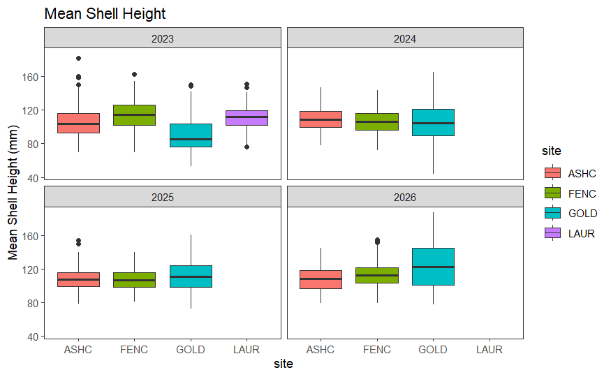

```r
ggplot(data=data_all, aes(x=site, y=height_mm, fill=site)) +
  geom_boxplot()+  #scale_fill_manual(values=c("forestgreen","orange", "purple"))+
  theme_bw() +  theme(panel.grid.major = element_blank(), panel.grid.minor = element_blank())+
  #theme(axis.text.x = element_text(angle = 90, vjust = 0.5, hjust=1))+
  labs(title="Mean Shell Height ", x ="site", y = "Mean Shell Height (mm)") + facet_wrap(.~year)
```

#Body condition

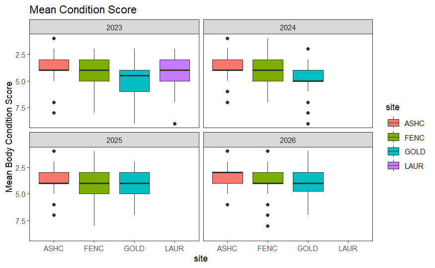

```r
ggplot(data=data_all, aes(x=site, y=condition_score, fill=site)) +
  geom_boxplot()+  #scale_fill_manual(values=c("forestgreen","orange", "purple"))+
  theme_bw() +  theme(panel.grid.major = element_blank(), panel.grid.minor = element_blank())+
  #theme(axis.text.x = element_text(angle = 90, vjust = 0.5, hjust=1))+
  labs(title="Mean Condition Score ", x ="site", y = "Mean Body Condition Score")+ scale_y_reverse()+ facet_wrap(.~year)
```

```r
mean_body_condition <- data_all %>%
  dplyr::group_by(site, month, year)%>%
  dplyr::summarize(mean_bsc = mean(condition_score, na.rm = TRUE))
mean_body_condition
```

| site | month | year | mean_bsc |
| --- | --- | --- | --- |
| ASHC | Jan | 2025 | 4.033333 |
| ASHC | Jan | 2026 | 3.233333 |
| ASHC | Feb | 2025 | 3.933333 |
| ASHC | Feb | 2026 | 3.066667 |
| ASHC | March | 2024 | 4.066667 |
| ASHC | March | 2025 | 3.800000 |
| ASHC | March | 2026 | 3.500000 |
| ASHC | April | 2023 | NaN |
| ASHC | April | 2024 | 4.033333 |
| ASHC | April | 2025 | 3.766667 |

[output cut: 99 more lines]

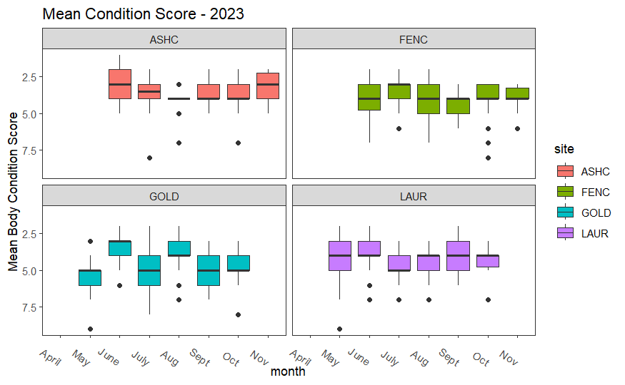

```r
#for overlay graph
#mean_bcs_ashc <- mean_body_condition %>%
  #filter(site == "ASHC") %>%
  #filter(year == "2024")

#Mean body condtion scores - 2023
data_2023 <- data_all%>%  filter(year=="2023")

ggplot(data=data_2023, aes(x=month, y=condition_score, group = month, fill = site)) +
  geom_boxplot()+
  theme_bw() +  theme(panel.grid.major = element_blank(), panel.grid.minor = element_blank())+
  theme(axis.text.x = element_text(angle = -35, vjust = 0.5, hjust=1))+
  labs(title="Mean Condition Score - 2023", x ="month", y = "Mean Body Condition Score")+ scale_y_reverse()+facet_wrap(~site)
```

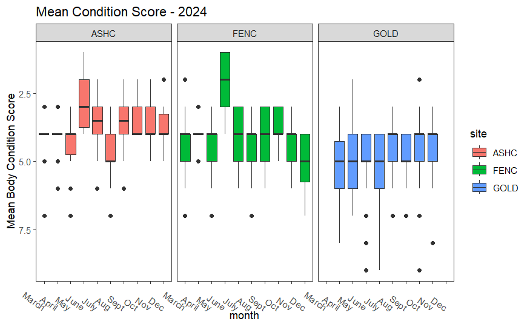

```r
#Mean body condtion scores - 2024
data_2024 <- data_all%>%  filter(year=="2024")

ggplot(data=data_2024, aes(x=month, y=condition_score, group = month, fill = site)) +
  geom_boxplot()+
  theme_bw() +  theme(panel.grid.major = element_blank(), panel.grid.minor = element_blank())+
  theme(axis.text.x = element_text(angle = -35, vjust = 0.5, hjust=1))+
  labs(title="Mean Condition Score - 2024", x ="month", y = "Mean Body Condition Score")+ scale_y_reverse()+facet_wrap(~site)
```

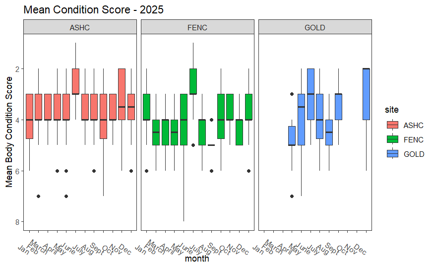

```r
#Mean body condition scores - 2025
data_2025 <- data_all%>%  filter(year=="2025")

ggplot(data=data_2025, aes(x=month, y=condition_score, group = month, fill = site)) +
  geom_boxplot()+
  theme_bw() +  theme(panel.grid.major = element_blank(), panel.grid.minor = element_blank())+
  theme(axis.text.x = element_text(angle = -35, vjust = 0.5, hjust=1))+
  labs(title="Mean Condition Score - 2025", x ="month", y = "Mean Body Condition Score")+ scale_y_reverse()+facet_wrap(~site)
```

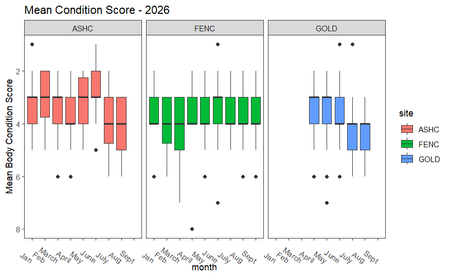

```r
#Mean body condition scores - 2026
data_2026 <- data_all%>%  filter(year=="2026")

ggplot(data=data_2026, aes(x=month, y=condition_score, group = month, fill = site)) +
  geom_boxplot()+
  theme_bw() +  theme(panel.grid.major = element_blank(), panel.grid.minor = element_blank())+
  theme(axis.text.x = element_text(angle = -35, vjust = 0.5, hjust=1))+
  labs(title="Mean Condition Score - 2026", x ="month", y = "Mean Body Condition Score")+ scale_y_reverse()+facet_wrap(~site)
```

#Proportions graph Body condition scores

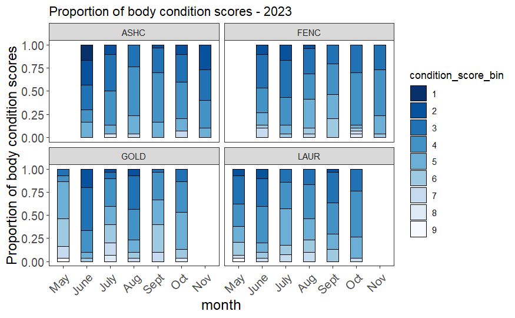

```r
#Proportions graph Body condition scores - 2023

df_BCS_proportions2023<- data_2023 %>%
  mutate(condition_score_numeric = as.numeric(condition_score),condition_score_bin = case_when(condition_score == 1 ~ "1", condition_score == 2 ~"2",condition_score == 3 ~ "3", condition_score == 4 ~"4",condition_score == 5 ~ "5", condition_score == 6 ~"6",condition_score == 7 ~ "7", condition_score == 8 ~"8", condition_score ==9 ~"9", TRUE ~ as.character(condition_score))) %>%

  group_by(site, month, year, condition_score_bin) %>% dplyr ::summarise(Count= n()) %>%

  ungroup() %>%
  mutate(Proportion = Count/sum(Count))
df_BCS_proportions2023<- na.omit(df_BCS_proportions2023)

BCS_proportion_all_2023<- ggplot(data=df_BCS_proportions2023, aes(x=month, y= Proportion, fill=condition_score_bin)) +
  geom_bar(width = .5, stat="identity", position = "fill", colour = "black")+
   theme_bw() +  theme(panel.grid.major = element_blank(), panel.grid.minor = element_blank())+
  theme(axis.text.x = element_text(angle = 45, vjust = 1, hjust=1))+
  labs(title="Proportion of body condition scores - 2023", x ="month", y = "Proportion of body condition scores ")+ theme(axis.title.y = element_text(size = rel(1.3), angle =90), axis.title.x = element_text(size = rel(1.3), angle = 0))+
  theme(axis.text=element_text(size=12))+
  scale_fill_brewer(palette = "Blues", direction = -1)+
  facet_wrap(~ site)

BCS_proportion_all_2023
```

```r
#pdf(paste0(path = "Lab_Data_TissueProcessing/output" ,"/all_BCS_proportion_2023.pdf"), height = 7, width = 13)
#print(BCS_proportion_all_2023)
#dev.off()
```

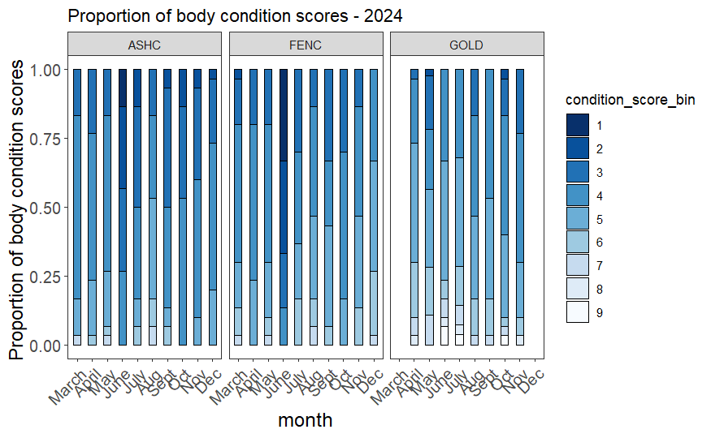

```r
#Proportions graph Body condition scores - 2024
df_BCS_proportions2024<- data_2024 %>%
  mutate(condition_score_numeric = as.numeric(condition_score),condition_score_bin = case_when(condition_score == 1 ~ "1", condition_score == 2 ~"2",condition_score == 3 ~ "3", condition_score == 4 ~"4",condition_score == 5 ~ "5", condition_score == 6 ~"6",condition_score == 7 ~ "7", condition_score == 8 ~"8", condition_score ==9 ~"9", TRUE ~ as.character(condition_score))) %>%

  group_by(site, month, year, condition_score_bin) %>% dplyr ::summarise(Count= n()) %>%

  ungroup() %>%
  mutate(Proportion = Count/sum(Count))
df_BCS_proportions2024<- na.omit(df_BCS_proportions2024)

BCS_proportion_all_2024<- ggplot(data=df_BCS_proportions2024, aes(x=month, y= Proportion, fill=condition_score_bin)) +
  geom_bar(width = .5, stat="identity", position = "fill", colour = "black")+
   theme_bw() +  theme(panel.grid.major = element_blank(), panel.grid.minor = element_blank())+
  theme(axis.text.x = element_text(angle = 45, vjust = 1, hjust=1))+
  labs(title="Proportion of body condition scores - 2024", x ="month", y = "Proportion of body condition scores ")+ theme(axis.title.y = element_text(size = rel(1.3), angle =90), axis.title.x = element_text(size = rel(1.3), angle = 0))+
  theme(axis.text=element_text(size=12))+
  scale_fill_brewer(palette = "Blues", direction = -1)+
  facet_wrap(~ site)

BCS_proportion_all_2024
```

```r
#pdf(paste0(path = "Lab_Data_TissueProcessing/output" ,"/all_BCS_proportion_2024.pdf"), height = 7, width = 13)
#print(BCS_proportion_all_2024)
#dev.off()
```

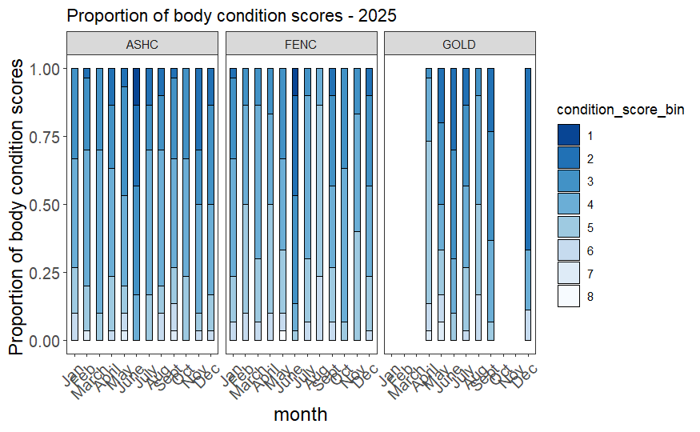

```r
#Proportions graph Body condition scores - 2025
df_BCS_proportions2025<- data_2025 %>%
  mutate(condition_score_numeric = as.numeric(condition_score),condition_score_bin = case_when(condition_score == 1 ~ "1", condition_score == 2 ~"2",condition_score == 3 ~ "3", condition_score == 4 ~"4",condition_score == 5 ~ "5", condition_score == 6 ~"6",condition_score == 7 ~ "7", condition_score == 8 ~"8", condition_score ==9 ~"9", TRUE ~ as.character(condition_score))) %>%

  group_by(site, month, year, condition_score_bin) %>% dplyr ::summarise(Count= n()) %>%

  ungroup() %>%
  mutate(Proportion = Count/sum(Count))
df_BCS_proportions2025<- na.omit(df_BCS_proportions2025)

BCS_proportion_all_2025<- ggplot(data=df_BCS_proportions2025, aes(x=month, y= Proportion, fill=condition_score_bin)) +
  geom_bar(width = .5, stat="identity", position = "fill", colour = "black")+
   theme_bw() +  theme(panel.grid.major = element_blank(), panel.grid.minor = element_blank())+
  theme(axis.text.x = element_text(angle = 45, vjust = 1, hjust=1))+
  labs(title="Proportion of body condition scores - 2025", x ="month", y = "Proportion of body condition scores ")+ theme(axis.title.y = element_text(size = rel(1.3), angle =90), axis.title.x = element_text(size = rel(1.3), angle = 0))+
  theme(axis.text=element_text(size=12))+
  scale_fill_brewer(palette = "Blues", direction = -1)+
  facet_wrap(~ site)#, scales = "free")

BCS_proportion_all_2025
```

```r
# pdf(paste0(path = "Lab_Data_TissueProcessing/output" ,"/all_BCS_proportion_2025.pdf"), height = 7, width = 13)
# print(BCS_proportion_all_2025)
# dev.off()
```

```r
#Proportions graph Body condition scores - 2026
df_BCS_proportions2026<- data_2026 %>%
  mutate(condition_score_numeric = as.numeric(condition_score),condition_score_bin = case_when(condition_score == 1 ~ "1", condition_score == 2 ~"2",condition_score == 3 ~ "3", condition_score == 4 ~"4",condition_score == 5 ~ "5", condition_score == 6 ~"6",condition_score == 7 ~ "7", condition_score == 8 ~"8", condition_score ==9 ~"9", TRUE ~ as.character(condition_score))) %>%

  group_by(site, month, year, condition_score_bin) %>% dplyr ::summarise(Count= n()) %>%

  ungroup() %>%
  mutate(Proportion = Count/sum(Count))
df_BCS_proportions2026<- na.omit(df_BCS_proportions2026)

BCS_proportion_all_2026<- ggplot(data=df_BCS_proportions2026, aes(x=month, y= Proportion, fill=condition_score_bin)) +
  geom_bar(width = .5, stat="identity", position = "fill", colour = "black")+
   theme_bw() +  theme(panel.grid.major = element_blank(), panel.grid.minor = element_blank())+
  theme(axis.text.x = element_text(angle = 45, vjust = 1, hjust=1))+
  labs(title="Proportion of body condition scores - 2026", x ="Month", y = "Proportion of body condition scores ")+ theme(axis.title.y = element_text(size = rel(1.3), angle =90), axis.title.x = element_text(size = rel(1.3), angle = 0))+
  theme(axis.text=element_text(size=12))+
  scale_fill_brewer(palette = "Blues", direction = -1)+
  facet_wrap(~ site)#, scales = "free")

BCS_proportion_all_2026

pdf(paste0(path = "Lab_Data_TissueProcessing/output" ,"/all_BCS_proportion_2026.pdf"), height = 7, width = 13)
```

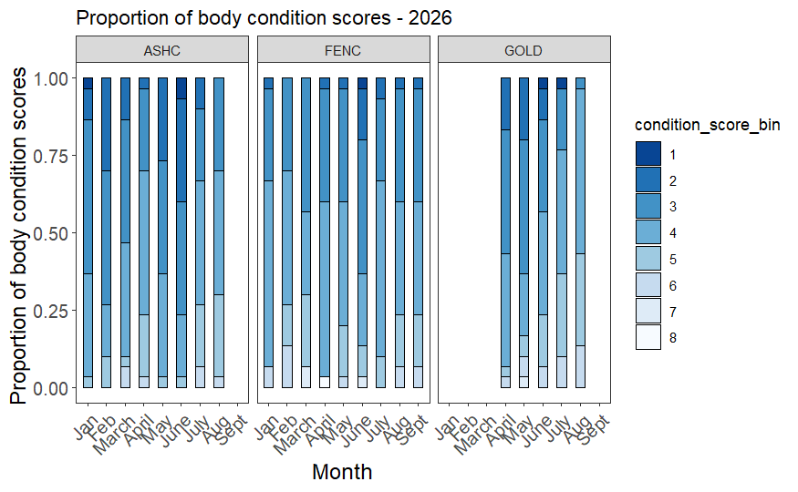

```r
print(BCS_proportion_all_2026)
dev.off()
```

```r
#Winter sampling
# winter_bcs <- rbind(df_BCS_proportions2024, df_BCS_proportions2025)
#
# winter_bcs <- winter_bcs %>% filter(month == "Dec"|month == "Jan"|month == "Feb")
#
# BCS_proportion_winter<- ggplot(data=winter_bcs, aes(x=factor (month, level=c('Dec', 'Jan', 'Feb')), y= Proportion, fill=condition_score_bin)) +
#   geom_bar(width = .5, stat="identity", position = "fill", colour = "black")+
#    theme_bw() +  theme(panel.grid.major = element_blank(), panel.grid.minor = element_blank())+
#   theme(axis.text.x = element_text(angle = 45, vjust = 1, hjust=1))+
#   labs(title="Proportion of body condition scores - Winter Sampling 2024-2025", x ="Month", y = "Proportion of body condition scores ")+ theme(axis.title.y = element_text(size = rel(1.3), angle =90), axis.title.x = element_text(size = rel(1.3), angle = 0))+
#   theme(axis.text=element_text(size=12))+
#   scale_fill_brewer(palette = "Blues", direction = -1)+
#   facet_wrap(~ site)
#
# BCS_proportion_winter
```

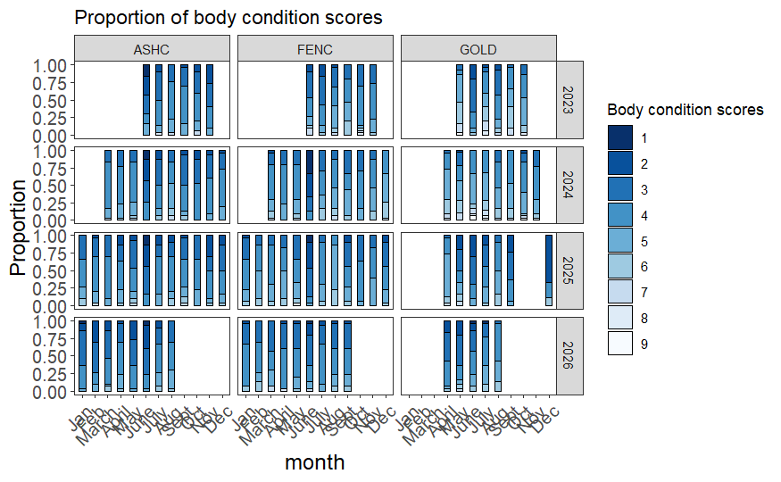

```r
# Proportion per month of intensity scores at three sites during 2023 - 2026
df_bcs_proportions_new <- rbind(df_BCS_proportions2023, df_BCS_proportions2024, df_BCS_proportions2025, df_BCS_proportions2026)

df_bcs_proportions_new<- df_bcs_proportions_new %>% filter(!site=="LAUR")

ggplot(data=df_bcs_proportions_new, aes(x=month, y= Proportion, fill=condition_score_bin)) +
  geom_bar(width = .5, stat="identity", position = "fill",colour = "black")+
   theme_bw() +  theme(panel.grid.major = element_blank(), panel.grid.minor = element_blank())+
  theme(axis.text.x = element_text(angle = 45, vjust = 1, hjust=1))+
  labs(fill ="Body condition scores")+
  labs(title="Proportion of body condition scores", x ="month", y = "Proportion")+ theme(axis.title.y = element_text(size = rel(1.3), angle =90), axis.title.x = element_text(size = rel(1.3), angle = 0))+
  theme(axis.text=element_text(size=12))+
scale_fill_brewer(palette = "Blues", direction = -1)+
   #scale_x_continuous("Month", breaks = c(3,4,5,6,7,8,9,10))+
  facet_grid(year ~site)
```

###### Preliminary Statistics on ALL body condition data

#kruskal- Wallis test - non-parameteric test used to compare three or more independent groups to see if there distributions differ , alternative to one way ANOVA, suitable for ordinal or continous data #General Linear Mixed Model (glmmTMB function)

```r
mean_body_condition
```

| site | month | year | mean_bsc |
| --- | --- | --- | --- |
| ASHC | Jan | 2025 | 4.033333 |
| ASHC | Jan | 2026 | 3.233333 |
| ASHC | Feb | 2025 | 3.933333 |
| ASHC | Feb | 2026 | 3.066667 |
| ASHC | March | 2024 | 4.066667 |
| ASHC | March | 2025 | 3.800000 |
| ASHC | March | 2026 | 3.500000 |
| ASHC | April | 2023 | NaN |
| ASHC | April | 2024 | 4.033333 |
| ASHC | April | 2025 | 3.766667 |

[output cut: 99 more lines]

```r
data_all
```

| lab_id | date_collected | site | lab_sample | date_processed | height_mm | condition | sample_notes | mantle_rftm | ggr1_frozen | ggr2_etoh | cross_histology | date_davidsons | date_etoh | ...15 | ...16 | ...17 | ww_total_g | length_mm | width_mm | dissection_notes | ggr1_etoh | adductor_etoh | ...21 | ...22 | ...23 | ...24 | ...25 | ...26 | ...27 | … |
| --- | --- | --- | --- | --- | --- | --- | --- | --- | --- | --- | --- | --- | --- | --- | --- | --- | --- | --- | --- | --- | --- | --- | --- | --- | --- | --- | --- | --- | --- | --- |
| 0125ASHC_01 | 2025-01-06 | ASHC | 1 | 2025-01-06 | 93.24 | 5_fair | NA | TRUE | TRUE | TRUE | TRUE | 2025-01-06 | 2025-01-08 | NA | NA | NA | NA | NA | NA | NA | NA | NA | NA | NA | NA | NA | NA | NA | NA | … |
| 0125ASHC_02 | 2025-01-06 | ASHC | 2 | 2025-01-06 | 97.88 | 4_fair_plus | NA | TRUE | TRUE | TRUE | TRUE | 2025-01-06 | 2025-01-08 | NA | NA | NA | NA | NA | NA | NA | NA | NA | NA | NA | NA | NA | NA | NA | NA | … |
| 0125ASHC_03 | 2025-01-06 | ASHC | 3 | 2025-01-06 | 100.32 | 4_fair_plus | NA | TRUE | TRUE | TRUE | TRUE | 2025-01-06 | 2025-01-08 | NA | NA | NA | NA | NA | NA | NA | NA | NA | NA | NA | NA | NA | NA | NA | NA | … |
| 0125ASHC_04 | 2025-01-06 | ASHC | 4 | 2025-01-06 | 112.22 | 6_fair_minus | NA | TRUE | TRUE | TRUE | TRUE | 2025-01-06 | 2025-01-08 | NA | NA | NA | NA | NA | NA | NA | NA | NA | NA | NA | NA | NA | NA | NA | NA | … |
| 0125ASHC_05 | 2025-01-06 | ASHC | 5 | 2025-01-06 | 98.98 | 5_fair | NA | TRUE | TRUE | TRUE | TRUE | 2025-01-06 | 2025-01-08 | NA | NA | NA | NA | NA | NA | NA | NA | NA | NA | NA | NA | NA | NA | NA | NA | … |
| 0125ASHC_06 | 2025-01-06 | ASHC | 6 | 2025-01-06 | 93.90 | 6_fair_minus | NA | TRUE | TRUE | TRUE | TRUE | 2025-01-06 | 2025-01-08 | NA | NA | NA | NA | NA | NA | NA | NA | NA | NA | NA | NA | NA | NA | NA | NA | … |
| 0125ASHC_07 | 2025-01-06 | ASHC | 7 | 2025-01-06 | 115.85 | 3_good_minus | NA | TRUE | TRUE | TRUE | TRUE | 2025-01-06 | 2025-01-08 | NA | NA | NA | NA | NA | NA | NA | NA | NA | NA | NA | NA | NA | NA | NA | NA | … |
| 0125ASHC_08 | 2025-01-06 | ASHC | 8 | 2025-01-06 | 112.20 | 5_fair | NA | TRUE | TRUE | TRUE | TRUE | 2025-01-06 | 2025-01-08 | NA | NA | NA | NA | NA | NA | NA | NA | NA | NA | NA | NA | NA | NA | NA | NA | … |
| 0125ASHC_09 | 2025-01-06 | ASHC | 9 | 2025-01-06 | 80.79 | 6_fair_minus | NA | TRUE | TRUE | TRUE | TRUE | 2025-01-06 | 2025-01-08 | NA | NA | NA | NA | NA | NA | NA | NA | NA | NA | NA | NA | NA | NA | NA | NA | … |
| 0125ASHC_10 | 2025-01-06 | ASHC | 10 | 2025-01-06 | 121.88 | 4_fair_plus | NA | TRUE | TRUE | TRUE | TRUE | 2025-01-06 | 2025-01-08 | NA | NA | NA | NA | NA | NA | NA | NA | NA | NA | NA | NA | NA | NA | NA | NA | … |

[output cut: 990 more lines]

```r
#Is BC significantly different across sites?
#Is BC significantly different over time?
kruskal.test(condition_score ~ site ,data_all)
```

```
    Kruskal-Wallis rank sum test

data:  condition_score by site
Kruskal-Wallis chi-squared = 146.59, df = 3, p-value < 2.2e-16
```

```r
kruskal.test(condition_score ~ date_collected ,data_all)
```

```
    Kruskal-Wallis rank sum test

data:  condition_score by date_collected
Kruskal-Wallis chi-squared = 788.93, df = 99, p-value < 2.2e-16
```

```r
#Is BC different between sites independent of date?
#is BC different between dates independent of site?
#Does BC over time differ at each site? (interaction *)
glm_bc <- glmmTMB(condition_score ~ site * date_collected, data_all)
```

[output not shown]

#Shell Pathology - all data #Includes 2023 data and all data that is in the 2024 format

```r
shell_path <- list.files(path = "Lab_Data_TissueProcessing/raw_data/shell_pathology",                           # Identify all CSV files
 pattern = "*.csv", full.names = TRUE) %>%
lapply(read_csv) %>%   # Store all files in list
  bind_rows          # Combine data sets into one data set
shell_path <- shell_path %>% filter(!is.na(lab_id))

shell_path <- shell_path %>% select(-c("...14":"...26"))

write.csv(shell_path, "Master_files/shell_pathology_all_data.csv", row.names=FALSE)


#Writing summary for shell pathology

# Clean up, convert to integer, drop ID, etc.
shell_path_summary <- shell_path %>%
  # split `lab_id` into two parts
  separate(lab_id, into = c("Date_Site", "ID")) %>%
  # drop unwanted columns
  select(-pathology_notes, -ID) %>%
  # convert a set of logical (or whatever) columns to 0/1
  mutate(across(
    c(boring_sponge, polydora, conchiolin_mod_severe, mud_blister,
      pea_crab, gill_erosion, pale_digestive, discoloration,
      horn_add, cyst_abscess, tumor, oyster_drill,
      boring_snail, shell_scarring),
    ~ as.integer(as.logical(.))
  ))


# Compute a pathogen‐indicator sum *per sample* (row).
shell_path_summary <- shell_path_summary %>%
  mutate(
    Pathogen_count = rowSums(
      select(., boring_sponge, polydora, conchiolin_mod_severe, mud_blister,
             pea_crab, gill_erosion, pale_digestive, discoloration,
             horn_add, cyst_abscess, tumor, oyster_drill,
             boring_snail, shell_scarring),
      na.rm = TRUE
    )
  )

# Now group + summarise
shell_path_count <- shell_path_summary %>%
  group_by(Date_Site) %>%
  summarise(
    Sample_count = n(),
    across(
      c(boring_sponge, polydora, conchiolin_mod_severe, mud_blister,
        pea_crab, gill_erosion, pale_digestive, discoloration,
        horn_add, cyst_abscess, tumor, oyster_drill,
        boring_snail, shell_scarring, Pathogen_count),
      sum,
      na.rm = TRUE
    )
  ) %>%
  ungroup()
shell_path_count
```

| Date_Site | Sample_count | boring_sponge | polydora | conchiolin_mod_severe | mud_blister | pea_crab | gill_erosion | pale_digestive | discoloration | horn_add | cyst_abscess | tumor | oyster_drill | boring_snail | shell_scarring | Pathogen_count |
| --- | --- | --- | --- | --- | --- | --- | --- | --- | --- | --- | --- | --- | --- | --- | --- | --- |
| 0125ASHC | 30 | 0 | 22 | 26 | 25 | 4 | 4 | 0 | 0 | 6 | 1 | 0 | 0 | 0 | 30 | 118 |
| 0125FENC | 30 | 0 | 18 | 30 | 20 | 1 | 0 | 0 | 18 | 2 | 1 | 0 | 0 | 0 | 12 | 102 |
| 0126ASHC | 30 | 0 | 10 | 30 | 15 | 5 | 18 | 0 | 0 | 3 | 0 | 0 | 0 | 0 | 30 | 111 |
| 0126FENC | 30 | 1 | 18 | 28 | 25 | 5 | 17 | 0 | 0 | 1 | 0 | 0 | 0 | 0 | 30 | 125 |
| 0225ASHC | 30 | 0 | 7 | 27 | 11 | 6 | 5 | 2 | 0 | 0 | 1 | 0 | 0 | 0 | 29 | 88 |
| 0225FENC | 30 | 1 | 13 | 27 | 20 | 0 | 11 | 0 | 1 | 2 | 0 | 0 | 0 | 0 | 30 | 105 |
| 0226ASHC | 30 | 0 | 14 | 27 | 25 | 6 | 20 | 0 | 0 | 3 | 0 | 0 | 0 | 0 | 30 | 125 |
| 0324ASHC | 30 | 1 | 15 | 27 | 23 | 8 | 0 | 0 | 0 | 4 | 2 | 0 | 0 | 0 | 0 | 80 |
| 0324FENC | 30 | 0 | 24 | 30 | 27 | 4 | 0 | 0 | 0 | 4 | 7 | 0 | 0 | 0 | 0 | 96 |
| 0325ASHC | 30 | 0 | 16 | 27 | 14 | 9 | 17 | 0 | 0 | 9 | 0 | 0 | 0 | 0 | 29 | 121 |

[output cut: 98 more lines]

```r
shell_path_summary
```

| Date_Site | boring_sponge | shell_scarring | polydora | conchiolin_mod_severe | mud_blister | pea_crab | gill_erosion | pale_digestive | discoloration | horn_add | cyst_abscess | tumor | .lab_id | oyster_drill | boring_snail | Pathogen_count |
| --- | --- | --- | --- | --- | --- | --- | --- | --- | --- | --- | --- | --- | --- | --- | --- | --- |
| 0125ASHC | 0 | 1 | 1 | 1 | 1 | 0 | 0 | 0 | 0 | 0 | 0 | 0 | NA | NA | NA | 4 |
| 0125ASHC | 0 | 1 | 1 | 1 | 1 | 0 | 0 | 0 | 0 | 1 | 0 | 0 | NA | NA | NA | 5 |
| 0125ASHC | 0 | 1 | 1 | 1 | 1 | 0 | 0 | 0 | 0 | 1 | 0 | 0 | NA | NA | NA | 5 |
| 0125ASHC | 0 | 1 | 1 | 1 | 1 | 0 | 0 | 0 | 0 | 1 | 0 | 0 | NA | NA | NA | 5 |
| 0125ASHC | 0 | 1 | 1 | 1 | 1 | 1 | 1 | 0 | 0 | 0 | 0 | 0 | NA | NA | NA | 6 |
| 0125ASHC | 0 | 1 | 1 | 1 | 1 | 1 | 1 | 0 | 0 | 0 | 0 | 0 | NA | NA | NA | 6 |
| 0125ASHC | 0 | 1 | 1 | 1 | 1 | 0 | 0 | 0 | 0 | 0 | 0 | 0 | NA | NA | NA | 4 |
| 0125ASHC | 0 | 1 | 1 | 1 | 1 | 0 | 0 | 0 | 0 | 0 | 0 | 0 | NA | NA | NA | 4 |
| 0125ASHC | 0 | 1 | 1 | 1 | 1 | 1 | 1 | 0 | 0 | 0 | 0 | 0 | NA | NA | NA | 6 |
| 0125ASHC | 0 | 1 | 1 | 1 | 1 | 0 | 0 | 0 | 0 | 0 | 0 | 0 | NA | NA | NA | 4 |

[output cut: 990 more lines]

```r
write.csv(shell_path_count, "Lab_Data_TissueProcessing/output/shell_pathology_counts.csv", row.names=FALSE)
```

###### Preliminary Statistics on ALL body condition data

Individual site summaries and QAQC

# Ash Creek Summary

```r
df_ASHC<- data_all%>%
  filter(site=="ASHC")
df_ASHC
```

| lab_id | date_collected | site | lab_sample | date_processed | height_mm | condition | sample_notes | mantle_rftm | ggr1_frozen | ggr2_etoh | cross_histology | date_davidsons | date_etoh | ...15 | ...16 | ...17 | ww_total_g | length_mm | width_mm | dissection_notes | ggr1_etoh | adductor_etoh | ...21 | ...22 | ...23 | ...24 | ...25 | ...26 | ...27 | … |
| --- | --- | --- | --- | --- | --- | --- | --- | --- | --- | --- | --- | --- | --- | --- | --- | --- | --- | --- | --- | --- | --- | --- | --- | --- | --- | --- | --- | --- | --- | --- |
| 0125ASHC_01 | 2025-01-06 | ASHC | 1 | 2025-01-06 | 93.24 | 5_fair | NA | TRUE | TRUE | TRUE | TRUE | 2025-01-06 | 2025-01-08 | NA | NA | NA | NA | NA | NA | NA | NA | NA | NA | NA | NA | NA | NA | NA | NA | … |
| 0125ASHC_02 | 2025-01-06 | ASHC | 2 | 2025-01-06 | 97.88 | 4_fair_plus | NA | TRUE | TRUE | TRUE | TRUE | 2025-01-06 | 2025-01-08 | NA | NA | NA | NA | NA | NA | NA | NA | NA | NA | NA | NA | NA | NA | NA | NA | … |
| 0125ASHC_03 | 2025-01-06 | ASHC | 3 | 2025-01-06 | 100.32 | 4_fair_plus | NA | TRUE | TRUE | TRUE | TRUE | 2025-01-06 | 2025-01-08 | NA | NA | NA | NA | NA | NA | NA | NA | NA | NA | NA | NA | NA | NA | NA | NA | … |
| 0125ASHC_04 | 2025-01-06 | ASHC | 4 | 2025-01-06 | 112.22 | 6_fair_minus | NA | TRUE | TRUE | TRUE | TRUE | 2025-01-06 | 2025-01-08 | NA | NA | NA | NA | NA | NA | NA | NA | NA | NA | NA | NA | NA | NA | NA | NA | … |
| 0125ASHC_05 | 2025-01-06 | ASHC | 5 | 2025-01-06 | 98.98 | 5_fair | NA | TRUE | TRUE | TRUE | TRUE | 2025-01-06 | 2025-01-08 | NA | NA | NA | NA | NA | NA | NA | NA | NA | NA | NA | NA | NA | NA | NA | NA | … |
| 0125ASHC_06 | 2025-01-06 | ASHC | 6 | 2025-01-06 | 93.90 | 6_fair_minus | NA | TRUE | TRUE | TRUE | TRUE | 2025-01-06 | 2025-01-08 | NA | NA | NA | NA | NA | NA | NA | NA | NA | NA | NA | NA | NA | NA | NA | NA | … |
| 0125ASHC_07 | 2025-01-06 | ASHC | 7 | 2025-01-06 | 115.85 | 3_good_minus | NA | TRUE | TRUE | TRUE | TRUE | 2025-01-06 | 2025-01-08 | NA | NA | NA | NA | NA | NA | NA | NA | NA | NA | NA | NA | NA | NA | NA | NA | … |
| 0125ASHC_08 | 2025-01-06 | ASHC | 8 | 2025-01-06 | 112.20 | 5_fair | NA | TRUE | TRUE | TRUE | TRUE | 2025-01-06 | 2025-01-08 | NA | NA | NA | NA | NA | NA | NA | NA | NA | NA | NA | NA | NA | NA | NA | NA | … |
| 0125ASHC_09 | 2025-01-06 | ASHC | 9 | 2025-01-06 | 80.79 | 6_fair_minus | NA | TRUE | TRUE | TRUE | TRUE | 2025-01-06 | 2025-01-08 | NA | NA | NA | NA | NA | NA | NA | NA | NA | NA | NA | NA | NA | NA | NA | NA | … |
| 0125ASHC_10 | 2025-01-06 | ASHC | 10 | 2025-01-06 | 121.88 | 4_fair_plus | NA | TRUE | TRUE | TRUE | TRUE | 2025-01-06 | 2025-01-08 | NA | NA | NA | NA | NA | NA | NA | NA | NA | NA | NA | NA | NA | NA | NA | NA | … |

[output cut: 990 more lines]

```r
## Shell Height ##
st_height_ASHC <- summarySE(df_ASHC, measurevar="height_mm", groupvars=c("date_collected"))
st_height_ASHC
```

| date_collected | N | height_mm | sd | se | ci |
| --- | --- | --- | --- | --- | --- |
| 2023-04-23 | 30 | 94.64633 | 15.957911 | 2.913503 | 5.958782 |
| 2023-05-10 | 30 | 116.31067 | 17.539123 | 3.202191 | 6.549216 |
| 2023-06-12 | 30 | 105.11600 | 14.770644 | 2.696738 | 5.515449 |
| 2023-07-10 | 30 | 102.61033 | 15.534913 | 2.836274 | 5.800832 |
| 2023-08-07 | 30 | 110.41600 | 16.230649 | 2.963298 | 6.060624 |
| 2023-09-05 | 30 | 98.20967 | 11.729516 | 2.141507 | 4.379873 |
| 2023-10-03 | 30 | 114.05167 | 21.773987 | 3.975368 | 8.130540 |
| 2023-11-06 | 30 | 107.39133 | 18.797492 | 3.431937 | 7.019099 |
| 2024-03-14 | 30 | 100.36033 | 12.239075 | 2.234539 | 4.570146 |
| 2024-04-03 | 30 | 112.59433 | 14.057111 | 2.566466 | 5.249011 |

[output cut: 28 more lines]

```r
## Body Condition ##
#Excludes April and May due to scoring change. These months are scored categorically 'fat, medium, watery'.

st_condition_ASHC<- summarySE(df_ASHC, measurevar = "condition_score", groupvars = c("date_collected"))
st_condition_ASHC
```

| date_collected | N | condition_score | sd | se | ci |
| --- | --- | --- | --- | --- | --- |
| 2023-04-23 | 30 | NA | NA | NA | NA |
| 2023-05-10 | 30 | NA | NA | NA | NA |
| 2023-06-12 | 30 | 2.866667 | 1.3321834 | 0.2432223 | 0.4974455 |
| 2023-07-10 | 30 | 3.633333 | 1.1591713 | 0.2116348 | 0.4328417 |
| 2023-08-07 | 30 | 4.066667 | 0.8683450 | 0.1585374 | 0.3242453 |
| 2023-09-05 | 30 | 3.833333 | 0.7466400 | 0.1363172 | 0.2788000 |
| 2023-10-03 | 30 | 3.833333 | 1.2058288 | 0.2201532 | 0.4502639 |
| 2023-11-06 | 30 | 3.233333 | 0.9714310 | 0.1773582 | 0.3627383 |
| 2024-03-14 | 30 | 4.066667 | 0.7849153 | 0.1433053 | 0.2930922 |
| 2024-04-03 | 30 | 4.033333 | 0.7648905 | 0.1396493 | 0.2856148 |

[output cut: 28 more lines]

```r
mean_condition_ASHC <- st_condition_ASHC %>%
  filter(!is.na(condition_score)) %>% # Filter out rows where condition_score is NA
  group_by(date_collected)%>%
  summarize(mean_bcs = mean(condition_score, na.rm = TRUE))
mean_condition_ASHC
```

| date_collected | mean_bcs |
| --- | --- |
| 2023-06-12 | 2.866667 |
| 2023-07-10 | 3.633333 |
| 2023-08-07 | 4.066667 |
| 2023-09-05 | 3.833333 |
| 2023-10-03 | 3.833333 |
| 2023-11-06 | 3.233333 |
| 2024-03-14 | 4.066667 |
| 2024-04-03 | 4.033333 |
| 2024-05-01 | 4.200000 |
| 2024-06-10 | 2.700000 |

[output cut: 26 more lines]

```r
NA
```

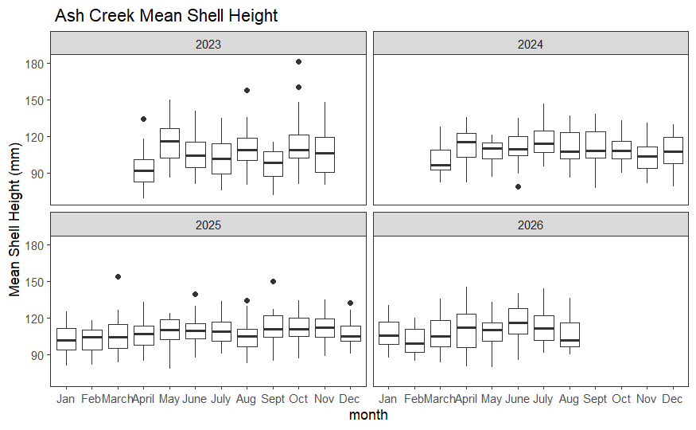

```r
ggplot(data=df_ASHC, aes(x=month, y=height_mm, group= month)) +
  geom_boxplot()+  #scale_fill_manual(values=c("forestgreen","orange", "purple"))+
  theme_bw() +  theme(panel.grid.major = element_blank(), panel.grid.minor = element_blank())+
  #theme(axis.text.x = element_text(angle = 90, vjust = 0.5, hjust=1))+
  labs(title=" Ash Creek Mean Shell Height ", x ="month", y = "Mean Shell Height (mm)")+facet_wrap(.~year)
```

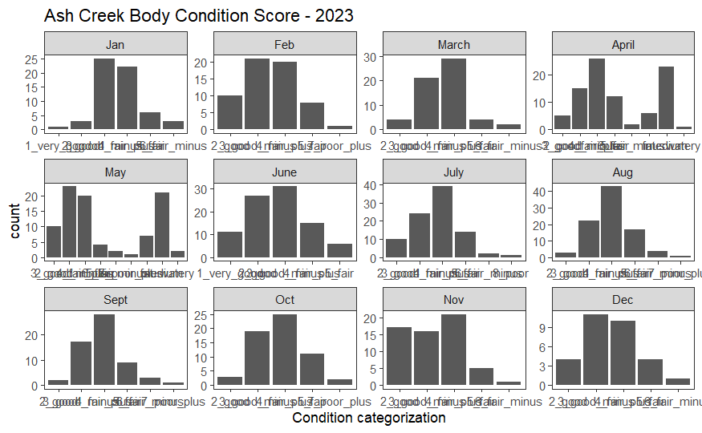

```r
#Condition distribution across all sample months - 2023
df_ASHC_2023 <- df_ASHC%>%  filter(!year=="2024")

ASHC_BCS_dist2023 <-ggplot(data=df_ASHC_2023, aes(x= condition)) +
  geom_bar()+  #scale_fill_manual(values=c("forestgreen","orange", "purple"))+
  theme_bw() +  theme(panel.grid.major = element_blank(), panel.grid.minor = element_blank())+
  #theme(axis.text.x = element_text(angle = 90, vjust = 0.5, hjust=1))+
  labs(title="Ash Creek Body Condition Score - 2023", x ="Condition categorization")+
  facet_wrap(~ month, scales = "free")
ASHC_BCS_dist2023
```

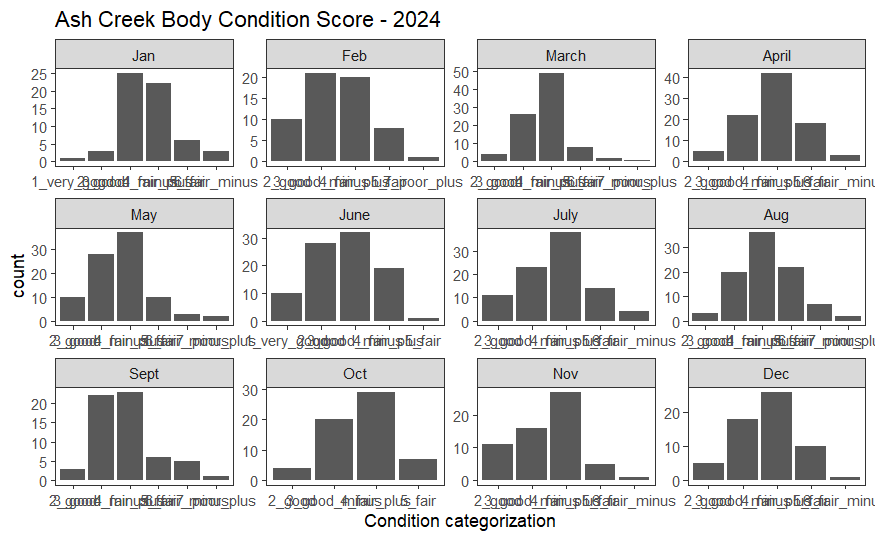

```r
#pdf(paste0(path = "Lab_Data_TissueProcessing/output" ,"/ASHC_BCS_dist_2023.pdf"), height = 7, width = 13)
#print(ASHC_BCS_dist2023)
#dev.off()

#Condition distribution across all sample months - 2024
df_ASHC_2024 <- df_ASHC%>%  filter(!year=="2023")

ASHC_BCS_dist2024 <-ggplot(data=df_ASHC_2024, aes(x= condition)) +
  geom_bar()+  #scale_fill_manual(values=c("forestgreen","orange", "purple"))+
  theme_bw() +  theme(panel.grid.major = element_blank(), panel.grid.minor = element_blank())+
  #theme(axis.text.x = element_text(angle = 90, vjust = 0.5, hjust=1))+
  labs(title="Ash Creek Body Condition Score - 2024", x ="Condition categorization")+
  facet_wrap(~ month, scales = "free")
ASHC_BCS_dist2024
```

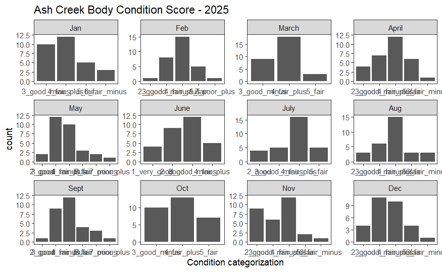

```r
#pdf(paste0(path = "Lab_Data_TissueProcessing/output" ,"/ASHC_BCS_dist_2024.pdf"), height = 7, width = 13)
#print(ASHC_BCS_dist2024)
#dev.off()

#Condition distribution across all sample months - 2025
df_ASHC_2025 <- df_ASHC%>%  filter(year=="2025")

ASHC_BCS_dist2025 <-ggplot(data=df_ASHC_2025, aes(x= condition)) +
  geom_bar()+  #scale_fill_manual(values=c("forestgreen","orange", "purple"))+
  theme_bw() +  theme(panel.grid.major = element_blank(), panel.grid.minor = element_blank())+
  #theme(axis.text.x = element_text(angle = 90, vjust = 0.5, hjust=1))+
  labs(title="Ash Creek Body Condition Score - 2025", x ="Condition categorization")+
  facet_wrap(~ month, scales = "free")
ASHC_BCS_dist2025
```

```r
# pdf(paste0(path = "Lab_Data_TissueProcessing/output" ,"/ASHC_BCS_dist_2025.pdf"), height = 7, width = 13)
# print(ASHC_BCS_dist2025)
# dev.off()

#Condition distribution across all sample months - 2026
df_ASHC_2026 <- df_ASHC%>%  filter(year=="2026")

ASHC_BCS_dist2026 <-ggplot(data=df_ASHC_2026, aes(x= condition)) +
  geom_bar()+  #scale_fill_manual(values=c("forestgreen","orange", "purple"))+
  theme_bw() +  theme(panel.grid.major = element_blank(), panel.grid.minor = element_blank())+
  #theme(axis.text.x = element_text(angle = 90, vjust = 0.5, hjust=1))+
  labs(title="Ash Creek Body Condition Score - 2026", x ="Condition categorization")+
  facet_wrap(~ month, scales = "free")
ASHC_BCS_dist2026

pdf(paste0(path = "Lab_Data_TissueProcessing/output" ,"/ASHC_BCS_dist_2026.pdf"), height = 7, width = 13)
```

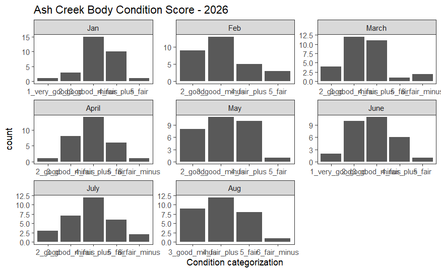

```r
print(ASHC_BCS_dist2026)
dev.off()
```

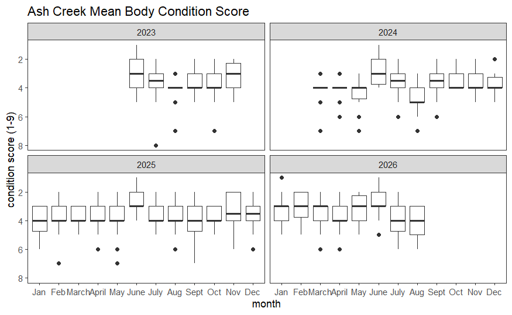

```r
#Mean Body condition per month
ggplot(data=df_ASHC, aes(x= month, y= condition_score, group = month)) +
  geom_boxplot()+  #scale_fill_manual(values=c("forestgreen","orange", "purple"))+
  theme_bw() +  theme(panel.grid.major = element_blank(), panel.grid.minor = element_blank())+
  #theme(axis.text.x = element_text(angle = 90, vjust = 0.5, hjust=1))+
  labs(title="Ash Creek Mean Body Condition Score ", x ="month", y= " condition score (1-9)") + scale_y_reverse()+facet_wrap(.~year)
```

#ASHC Proportions graph Body condition scores - all years

```r
ASHC_BCS_proportions<- df_ASHC %>%
  mutate(condition_score_numeric = as.numeric(condition_score),condition_score_bin = case_when(condition_score == 1 ~ "1", condition_score == 2 ~"2",condition_score == 3 ~ "3", condition_score == 4 ~"4",condition_score == 5 ~ "5", condition_score == 6 ~"6",condition_score == 7 ~ "7", condition_score == 8 ~"8", condition_score ==9 ~"9", TRUE ~ as.character(condition_score))) %>%
  group_by(site, month, condition_score_bin, year) %>% dplyr::summarise(Count= n()) %>%
  ungroup() %>%
  mutate(Proportion = Count/sum(Count))
ASHC_BCS_proportions<- na.omit(ASHC_BCS_proportions)

ASHC_BCS_proportions
```

| site | month | condition_score_bin | year | Count | Proportion |
| --- | --- | --- | --- | --- | --- |
| ASHC | Jan | 1 | 2026 | 1 | 0.000877193 |
| ASHC | Jan | 2 | 2026 | 3 | 0.002631579 |
| ASHC | Jan | 3 | 2025 | 10 | 0.008771930 |
| ASHC | Jan | 3 | 2026 | 15 | 0.013157895 |
| ASHC | Jan | 4 | 2025 | 12 | 0.010526316 |
| ASHC | Jan | 4 | 2026 | 10 | 0.008771930 |
| ASHC | Jan | 5 | 2025 | 5 | 0.004385965 |
| ASHC | Jan | 5 | 2026 | 1 | 0.000877193 |
| ASHC | Jan | 6 | 2025 | 3 | 0.002631579 |
| ASHC | Feb | 2 | 2025 | 1 | 0.000877193 |

[output cut: 152 more lines]

```r
BCS_proportion_ASHC<- ggplot(data=ASHC_BCS_proportions, aes(x=month, y= Proportion, fill=condition_score_bin)) +
  geom_bar(width = .5, stat="identity", position = "fill")+
   theme_bw() +  theme(panel.grid.major = element_blank(), panel.grid.minor = element_blank())+
  theme(axis.text.x = element_text(angle = 45, vjust = 1, hjust=1))+
  labs(title="Ash Creek Proportion of body condition scores June- November", x ="month", y = "Proportion of body condition scores ")+ theme(axis.title.y = element_text(size = rel(1.3), angle =90), axis.title.x = element_text(size = rel(1.3), angle = 0))+
  theme(axis.text=element_text(size=12))+
  facet_wrap(~ year)
 #scale_fill_brewer() +
  #facet_wrap(~ site)

BCS_proportion_ASHC

pdf(paste0(path = "Lab_Data_TissueProcessing/output" ,"/ASHC_BCS_proportion.pdf"), height = 7, width = 13)
```

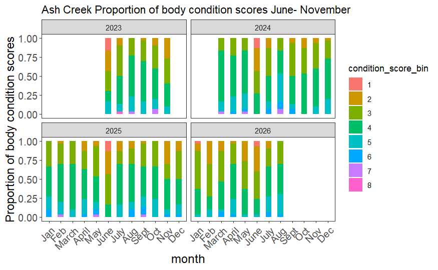

```r
print(BCS_proportion_ASHC)
dev.off()
```